# Plan Interanual 2025-29 SNIVCM

Estadísticas de Violencia Contra la Mujer y Violencia Sexual

Fecha de publicación

Diciembre 2024

# Introducción

En la planeación estratégica del presente plan se utilizó una metodología participativa donde a partir de ejercicios prácticos que contribuyen a identificar problemáticas, actores y su caracterización, las instituciones aportaron desde sus espacios y experiencias aspectos importantes a tener en cuenta para el fortalecimiento de la recopilación, producción y análisis estadístico.

Para el análisis situacional, se considera que el ejercicio realizado en el plan 2020-24 sigue vigente, ya que se indica que el mandato y marco conceptual del SNIVCM parte de la Ley Contra el Femicidio y Otras Formas de Violencia Contra la Mujer, así como de un marco internacional de Derechos como la Plataforma de Acción de Beijing, la Convención para la Eliminación de Todas las Formas de Violencia contra la Mujer (CEDAW) y la Convención Interamericana para Prevenir, Sancionar y Erradicar la Violencia Contra la Mujer.

A pesar del SNIVCM en su coordinación interinstitucional, aún se presentan problemáticas como la falta de asignación presupuestaria, la rotación del personal nombrado para las comisiones, vacíos de información y pocas acciones para la disminución del subregistro en variables de interés nacional como sexo, edad, pueblo de pertenencia y discapacidad.

Un primer paso fue el abordaje de actores mediante una metodología donde se les identificó y categorizó para luego establecer problemáticas y el papel que cada actor tiene en ellas. Esto se realizó con la ayuda de instrumentos como la matriz FODA, matriz poder interés, matriz de Vester, y árbol de objetivos y de problemas para ubicar las causas y efectos de la problemática general.

Aí mismo, se presenta un comparativo entre el FODA del plan anterior y el plan 2025-29 para identificar avances y retrocesos en materia estadística, que permitió la selección de actividades y actualización de la matriz de trabajo multianual a desarrollar en los próximos cinco años. Como resultado final y luego del análisis de problemáticas y actores, se concluyó que es necesario retomar los objetivos estratégicos del plan anterior, así como la visión, misión y las actividades inconclusas que presentan mayor relevancia para fortalecer las estadísticas del SNIVCM.

Finalmente, es importante mencionar que este ejercicio debe revisarse con las y los integrantes del SNIVCM para enriquecer la propuesta, atendiendo a que la planificación no es una camisa de fuerza sino una guía ajustable para el logro de los objetivos.

# 1 Análisis situacional

El SNIVCM es uno de los esfuerzos importantes en materia de generación estadística de forma homologada. Sin embargo, hay desafíos significativos, entre los cuales se puede mencionar el de los registros administrativos con los recursos estadísticos menos desarrollados. Este trabajo requiere mucho tiempo y esfuerzo para que se conviertan en estadísticas consistentes.

El sistema tiene como resultado final los datos estadísticos que la población puede consultar, pero ello es sólo una parte de lo que implica su operativización. El SNIVCM está constituido por muchos elementos interrelacionados, tales como su mandato, marco conceptual, y metodología de trabajo, así como los procesos de producción de las estadísticas para indicadores.

## 1.1 Mandato y marco conceptual

El SNIVCM tiene como marco conceptual y normativo fundamentalmente la Ley Contra el Femicidio y Otras Formas de Violencia Contra la Mujer, Decreto 22-2008 y la Ley Contra la Violencia Sexual, Explotación y Trata de Personas, Decreto 9-2009.

En el decreto 22-2008 en el artículo 20 se establece la obligatoriedad del Instituto Nacional de Estadística de generar, con la información que deben remitirle el Organismo Judicial, Ministerio Público, Procuraduría General de la Nación, Institución del Procurador de los Derechos Humanos, la Policía Nacional Civil, el Instituto de la Defensa Pública Penal, Bufetes Populares y cualquier otra institución que conozca de los delitos contemplados en la presente ley, indicadores e información estadística, debiendo crear un Sistema Nacional de Información sobre Violencia contra la Mujer.

La conceptualización de la violencia contra la mujer, su origen, ámbitos y tipología se encuentra además en ambas normativas mencionadas, la cual está alineada a los compromisos internacionales en materia de Derechos Humanos de las Mujeres de los cuales el Estado de Guatemala es signatario.

La definición de la violencia contra la mujer en el Decreto 22-2008 es “Toda acción u omisión basada en la pertenencia al sexo femenino que tenga como resultado el daño inmediato o ulterior, sufrimiento físico, sexual, económico o psicológico para la mujer, así como las amenazas de tales actos, la coacción o la privación arbitraria de la libertad, tanto si se produce en el ámbito público como en el ámbito privado”[^1].

La información del SNIVCM contiene los distintos tipos de violencia que se mencionan en la ley. El ámbito de relaciones registradas ve limitado su análisis por la ausencia del registro de la relación entre la víctima y el agresor. A pesar que esta variable tiene una ficha técnica con códigos y descripción en el diccionario de variables generales del SNIVCM, su asimilación en la captación del dato no es efectiva, ya que presenta un gran porcentaje de información con vacíos o inconsistencias.

## 1.2 Conformación y metodología de trabajo

La conformación de los y las integrantes del SNIVCM está determinada por las instituciones mencionadas en el artículo 20 del Decreto 22-2008: “…Organismo Judicial, Ministerio Público, Procuraduría General de la Nación, Institución del Procurador de los Derechos Humanos, la Policía Nacional Civil, el Instituto de la Defensa Pública Penal, Bufetes Populares y cualquier otra institución que conozca de los delitos contemplados en la presente ley”. Para el caso de las otras instituciones que no menciona el decreto, pero que son fuentes de información en el SNIVCM, se tiene al Sistema Penitenciario, el Instituto Nacional de Ciencias Forenses, Ministerio de Gobernación, Ministerio de Salud Pública, Ministerio de Educación, Instituto de la Víctima, además se cuenta con representantes del Bufete de la Universidad de San Carlos de Guatemala y de la Universidad Rafael Landívar.

La estructura organizativa y metodología de trabajo es uno de los mayores aportes del Plan Interanual 2016-2019, determinando que se debía trabajar en comisiones específicas con funciones que permitieran aprovechar el perfil de las y los integrantes.

La coordinación del SNIVCM recae, por mandato, en el Instituto Nacional de Estadística y sus funciones son las siguientes:

- Convocar a los representantes de las instituciones que lo integran.
- Acompañar y brindar asesoría técnica en materia estadística a las instituciones integrantes.
- Elaborar propuestas para el diseño, desarrollo y funcionamiento del SNIVCM.
- Administrar el sistema informático del SNIVCM.
- Oficializar, publicar y divulgar las estadísticas nacionales.

El desarrollo de estas funciones se realiza con un equipo de tres personas, quienes coordinan las comisiones de cabildeo, sistemas y contenido. Este equipo cuenta con perfiles de profesionales con estudios de leyes, informática y género. Es importante mencionar que todo el equipo está contratado bajo renglón presupuestario temporal, por lo que es necesario gestionar su permanencia.

## 1.3 Funciones de las comisiones de trabajo

Figura 1: Estructura SNIVCM

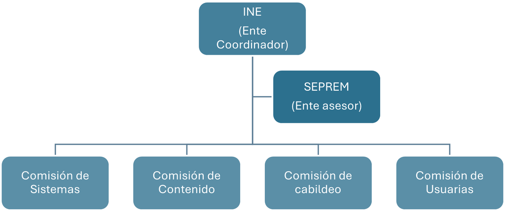

**Sistemas**

- Trabajar en equipo con los delegados de las otras comisiones para implementar y dar avance a lo establecido en el SNIVCM que esté relacionado directamente con las herramientas informáticas y/o sistemas.
- Trabajar en conjunto con todos los representantes de las instituciones de la comisión en función de garantizar el flujo de información para el SNIVCM.
- Socializar con la autoridad de la institución los cambios requeridos para los sistemas informáticos de acuerdo con lo establecido en las reuniones técnicas interinstitucionales del SNIVCM; conforme las aprobaciones de la autoridad y recursos de cada institución proceder a realizar los mismos.
- Preparar las bases de datos de acuerdo con lo solicitado por el INE.
- Enviar las bases de datos de acuerdo con lo solicitado por el INE, si fuere el responsable de realizar este envió de su institución.

**Contenido**

- Revisar las bases de datos estadísticos antes de remitirse al INE.
- Revisar y analizar los datos estadísticos de su institución para su posterior publicación.
- Promover el fortalecimiento de capacidades en el correcto registro de los datos de las personas atendidas y la importancia para la generación estadística, según instrumentos y metodología aprobada en el SNIVCM.
- Apoyar a representantes de la comisión de sistemas en la adecuada modificación de variables registradas o por registrar, según instrumentos y metodología aprobada en el SNIVCM, desde su especialidad.
- Si bien el INE solicita cada año, de manera oficial, la designación de representantes ante el SNIVCM, persiste la dificultad para el nombramiento de los 3 integrantes, así como una alta rotación de personal en cortos períodos, lo cual implica retomar nuevamente todos los procesos.

**Cabildeo**

- Solicitar el respaldo político a las autoridades de la institución que representa.
- Apoyar con gestiones ante las autoridades, los nombramientos y participación de los representantes de las distintas comisiones y otros a las reuniones convocadas.
- Dar seguimiento ante las autoridades, para los procesos del envío de información estadística al INE.
- Dar seguimiento para la participación de las máximas autoridades en las presentaciones de los documentos del sistema.

**Usuarias de información**

- El SNIVCM nace en el año 2008 en cumplimiento al Decreto 22-2008 como se menciona anteriormente, desde entonces ha tenido acercamiento con las usuarias y usuarios de información estadística, en un primer momento con la Coordinadora Nacional para la Prevención de la Violencia Intrafamiliar y en contra de la Mujer –CONAPREVI-, y las organizaciones que la conforman.
- En esta comisión entre otros aportes, se ha desarrollado un importante trabajo de validación del marco conceptual de la primera encuesta de violencia contra la mujer. Sin embargo, para potenciar el trabajo de la comisión es necesario establecer su funcionamiento y los aportes que debe generar en el marco del SNIVCM, para ello se deben describir el perfil de los y las representantes, así como las funciones que deben desarrollar.

## 1.4 La producción estadística y sus procesos

En el artículo 20 de la Ley Contra el Femicidio y Otras Formas de Violencia se indica que el INE tiene obligatoriedad de generar indicadores e información estadística con los datos que le remitan diferentes instituciones. La referencia a “indicadores e información estadística” es muy amplia por lo que desde 2008 se ha generado producción estadística basada principalmente en la participación de las instituciones en los distintos procesos de abordaje a la violencia contra las mujeres, la atención en salud, la recepción de las denuncias y conocimientos de los casos, la investigación, las evaluaciones a las víctimas, el acompañamiento, las sentencias y algunos procesos de reparación.

Esta producción está contenida en varias publicaciones, la primera una recopilación de 6 años 2008-2013, la segunda de 3 años 2014-2016, y a partir de 2017 se realiza una publicación anual de indicadores. Así mismo, desde 2022 se publican cuadros del primer y segundo semestre. La periodicidad de las publicaciones es evidencia del avance en la generación de información actualizada y continua puesta a disposición de los usuarios.

La otra gran referencia de la producción son los compromisos internacionales en materia de derechos de las mujeres que en realidad son los que han marcado la ruta de la producción, por ejemplo la Convención Sobre la Eliminación de Todas las Formas de Discriminación Contra la Mujer, CEDAW por sus siglas en inglés, en la recomendación 35 establece que se debe generar número de denuncias de todas las formas de violencia, algo con lo que ya cuenta el SNIVCM, pero además menciona que se debe medir el tiempo necesario para la resolución de las causas, algo que también la Convención Belem do Pará le pide a los Estados para el seguimiento de la convención y que representa un reto para el SNIVCM.

En cuanto a los procesos de la producción hay dos aspectos donde se han tenido grandes avances. El primero de ellos es la composición de la información estadística, para ello es fundamental la implementación del documento de variables generales en los sistemas informáticos de las instituciones integrantes, este documento contiene 65 variables que caracteriza a las personas (víctimas y agresores), hechos y registros.

Una vez incorporadas las variables, el otro reto es mejorar los procesos para el llenado de las mismas, ejemplo de esto es el trabajo que debe desarrollarse con la variable relación victima agresor[^2] que en muchos de los registros mencionados no tiene valores y se publica únicamente con datos de la Policía Nacional Civil y la Procuraduría de los Derechos Humanos. Por otro lado, el pueblo de pertenencia, discapacidad y ocupación tienen bajos o nulos valores, pues no se registran, ya sea porque no se pregunta o porque se pregunta de manera inadecuada. Estos aspectos del proceso de producción de los datos, se describe en la Tabla 1.

Tabla 1: Procesos para la producción de datos

[output not shown]

## 1.5 De la coordinación e implementación del SNIVCM

La Ley contra el Femicidio y otras Formas de Violencia Contra la Mujer establece la construcción de un Sistema Nacional de Información, sin embargo no indica muchos aspectos sobre la coordinación, solamente indica que se deben crear indicadores y estadísticas, y que las entidades referidas “deberán implementar los mecanismos adecuados, de acuerdo a su régimen interno, para el cumplimiento de esta obligación”. Estos mecanismos pueden ser desde creación de unidades específicas para generar la información, hasta establecer recursos en el presupuesto de todas las instituciones para el funcionamiento.

En cuanto a la asignación de recursos la ley establece que se debe asignar los recursos dentro del Presupuesto de Ingresos y Egresos del Estado, para el cumplimiento de la presente ley mencionando algunas instituciones, pero no al INE, lo cual representó la perdida de una oportunidad para fortalecer al instituto. Para solventar esta situación es necesario establecer convenios de cooperación institucional para el SNIVCM.

# 2 Identificación de la problemática

En el plan anterior se tuvieron algunas dificultades y limitantes con respecto al tiempo y desarrollo de reuniones, cuestión que en el plan 2025-29 se buscó evitar aprovechando las reuniones ordinarias bimensuales durante 2024 para construir un plan con los aportes de todas las instituciones que conforman el SNIVCM.

Para ello se utilizaron metodologías participativas y de planeación estratégica para la identificación, selección y priorización de problemáticas y actores que orientan las actividades a desarrollar durante los próximos cinco años.

## 2.1 Gráfico de Vester

Para el desarrollo de esta herramienta se identificó una lista de problemas, para luego interrelacionarlos de manera horizontal y de doble vía, tomando como referencia los criterios que se presentan a continuación:

*Valor Descripción*

- 0 ⊳ No existe relación de causalidad directa entre el primer y el segundo problema
- 1 ⊳ Existe una relación de causalidad indirecta entre el primer y segundo problema
- 2 ⊳ Existe una relación de causalidad medianamente directa entre el primer y segundo problema
- 3 ⊳ Existe una relación de causalidad directa

Este fue un instrumento utilizado en el plan anterior que fue de mucha ayuda, por lo que se actualizó mediante los aportes de las instituciones que asistieron a las reuniones, lo cual se plasma en llenado de la Matriz de Vester promediada de todas las instituciones que participaron, la cual se presenta en los anexos, pero para fines de mejor interpretación se tiene su versión sintetizada en la Tabla 2, donde las sumatoria de valoraciones de las interrelaciones en las filas representa la influencia y la sumatoria de las interrelaciones en las columnas la dependencia, dando como resultado el gráfico de Vester en la Figura 2, que refleja una ruta a tener en cuenta para la priorización de problemas.

**Matriz de Vester**

Tabla 2: Matriz de Vester

|  | Problema | Influencia | Dependencia |
| --- | --- | --- | --- |
| P1 | Métodos de análisis estadísticos deficientes | 14.0 | 14.1 |
| P2 | No se respeta el tiempo acordado para el envío de información por parte de las instituciones integrantes | 13.3 | 13.2 |
| P3 | Débil institucionalidad del SNIVCM | 17.3 | 17.7 |
| P4 | Alta rotación de personal en algunas comisiones | 13.4 | 12.7 |
| P5 | Desvinculación con mecanismos nacionales para el abordaje de la VCM | 13.0 | 14.5 |
| P6 | Falta de fortalecimiento para la calidad de los registros | 15.2 | 15.4 |
| P7 | Variables generales con información incompleta para el análisis de la problemática | 15.2 | 14.9 |
| P8 | Revíctimización de las víctima por VCM debido a procedimiento deficientes para su abordaje | 12.6 | 12.0 |
| P9 | Voluntad política de autoridades | 16.5 | 16.3 |
| P10 | Falta de presupuesto para el SNIVCM | 11.6 | 11.0 |
| P11 | Falta de estrategia de comunicación | 14.3 | 14.6 |

**Gráfico de Vester**

Figura 2: Gráfico de Vester

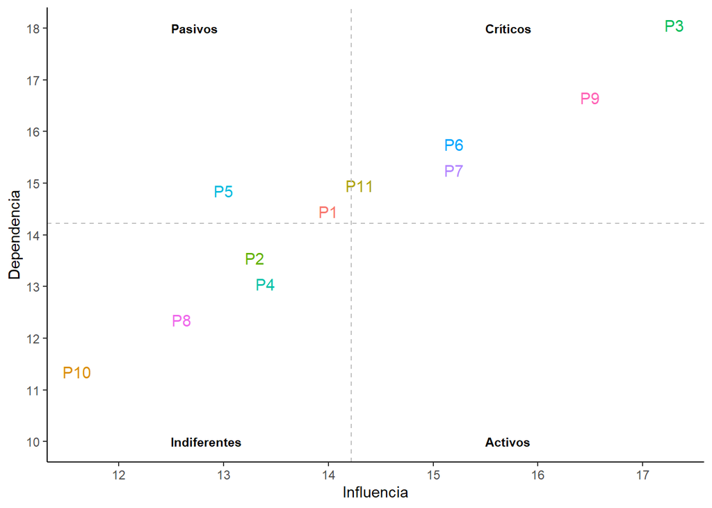

La interpretación de este gráfico orienta a tomar acciones puntuales con respecto a las problemáticas, para lo cual:

- Los problemas indiferentes se consideran de baja prioridad, ya que no causan ni son causados por otros. Entre estos se tiene la *falta de presupuesto para el SNIVCM, la revictimización por VCM, no se respeta el tiempo acordado para el envío de información y métodos de análisis estadísticos deficientes.*
- Los problemas pasivos son los que tienen poca causalidad sobre otros problemas, por lo que son los que pueden tener mayor facilidad para solucionarlos. Entre estos solo se tiene la *desvinculación de mecanismos nacionales para el abordaje de la VCM.*
- Los problemas críticos presentan una alta causalidad y consecuencias sobre otros problemas y su seguimiento debe ser constante, ya que su tratamiento inadecuado representa la aparición de otros problemas. Entre estos se tiene la *falta de estrategia de comunicación, variables con información incompleta, falta de fortalecimiento para la calidad de los registros, la voluntad política y la débil institucionalidad del SNIVCM.*

## 2.2 Árbol de problemas y objetivos

Para el desarrollo del árbol de problemas presentado en la Figura 3 se revisó una lluvia de ideas con preguntas generadoras logrando identificar una problemática central sobre todos los aspectos que persisten de planes anteriores, se establecieron ideas generales para dar como resultado causas y efectos del problema principal. Pero más importante que la problemática identificada, es como el árbol de problemas se puede convertir en los objetivos para el trabajo de los próximos 4 años, lo cual se presenta en la Figura 4.

Figura 3: Árbol de problemas

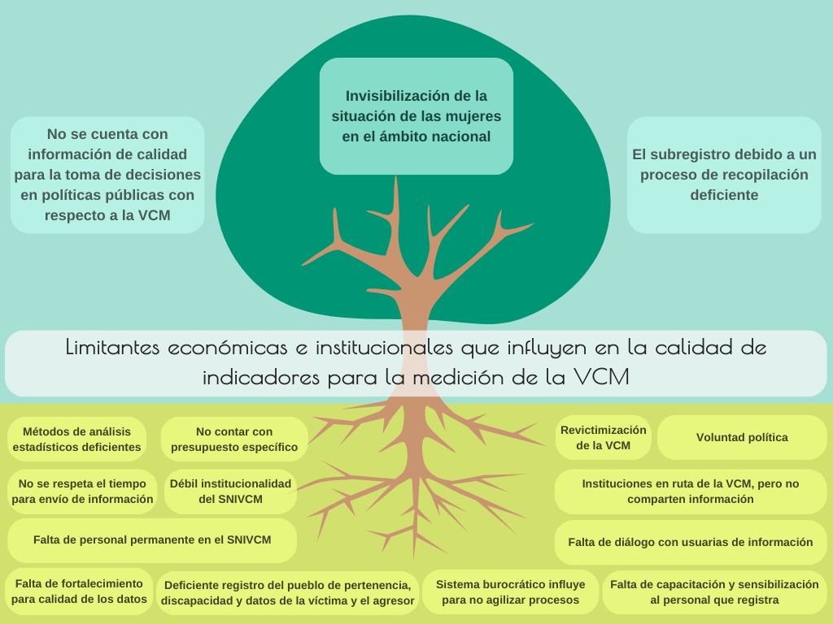

Figura 4: Árbol de objetivos

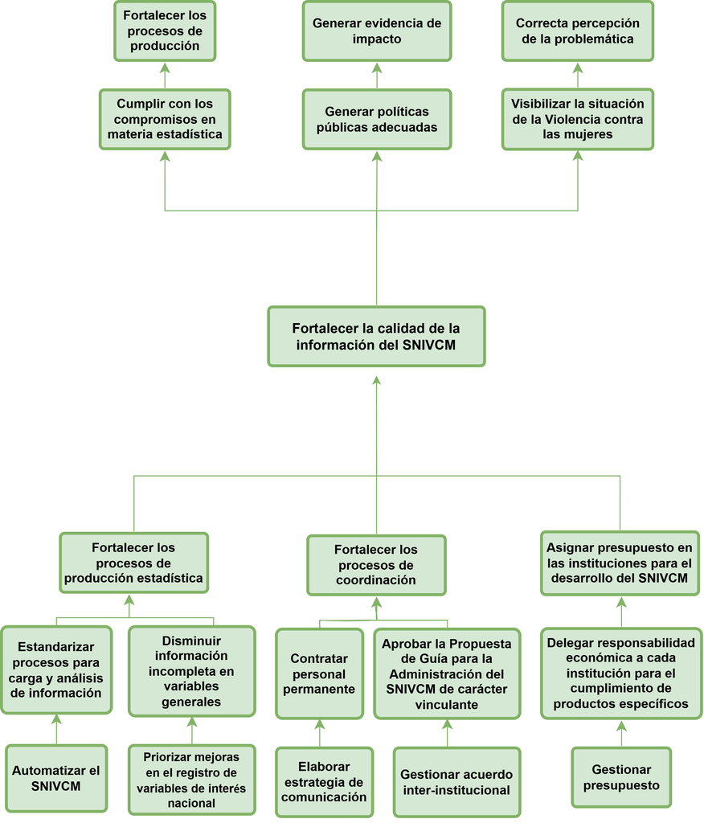

## 2.3 Comparativo FODA 2020-24 y 2025-29

El FODA (Fortalezas, Oportunidades, Debilidades y Amenazas) es una de las herramientas más utilizadas en el análisis de las organizaciones, sobre todo porque permite la participación de todos y todas las integrantes. El SNIVCM ya había realizado en el año 2019 y 2020 un ejercicio preliminar en donde se realizó una lluvia de ideas para crear una primera base para el FODA, el ejercicio a diferencia del año 2016 se hizo por comisiones y no en plenaria como en el 2015, como era de esperarse se tuvieron elementos comunes y algunas particularidades según la visión desde el trabajo de cada comisión, a continuación, se presenta el FODA realizado para 2020-24 en la Tabla 3 y su continuación para 2025 en la Tabla 4.

Identificando varios aspectos a retomar, para 2020-24 se tuvieron avances, por lo que es necesario proyectarse a fortalecer estos avances con un enfoque tecnológico y de mejora en la captación de los datos. Un avance es la Propuesta de Guía para la Administración del SNIVCM, pero es necesario establecer acuerdos institucionales para que sea vinculante.

Otro avance es en el tema metodológico, donde ya se cuenta con la actualización de documentos para la estandarización de variables generales y específicas, así como de evaluación sobre el funcionamiento de la plataforma receptora de información, contribuyendo a que las instituciones manejen los mismos términos sin dejar por un lado su mandato constitucional. Sin embargo, es necesario fortalecer la aplicación de estos estándares desde la captación de los datos.

En el análisis interno existen debilidades persistentes como la limitación de recursos que en el marco de la situación actual va a requerir alianzas, tanto con la cooperación internacional, que siempre ha sido una aliada importante para el SNIVCM, como la colaboración por parte de las y los integrantes, así como de las autoridades institucionales. Para el análisis externo la coincidencia en el cambio de autoridades institucionales se identifica como una amenaza por la posible disminución de apoyo que pudiera existir, pero una oportunidad identificada en ambos ejercicios es contar con el apoyo de organismos internacionales y los mandatos para generar estadísticas de violencia contra la mujer.

**FODA 20-24**

Tabla 3: FODA 2020-24

| Fortalezas (Internas) | Debilidades (Internas) |
| --- | --- |
| Capacidad de generar información estadística de VCM | Irregular participación de algunas instituciones en las diferentes comisiones |
| Capacidad de generar instrumentos metodológicos | Limitados recursos humanos y financieros para el desarrollo de las actividades del SNIVCM |
| Contar con una buena coordinación y comunicación interinstitucional | Falta de Software y Hardware adecuado |
| Haber iniciado procesos de innovación tecnológica | Resistencia al uso de nuevos sistemas informáticos |
| Contar con el apoyo e interés de las autoridades para el seguimiento de las actividades del SNIVCM | No contar con reglamento para las actividades del SNIVCM |
| Tener una metodología de trabajo en comisiones con funciones específicas | Resistencia a la incorporación de variables en los sistemas |
| Contar con procesos de formación | --------------------- |
| Normativa de creación del SNIVCM | --------------------- |
| Asesoría a la generación de estadísticas desde la perpectiva de género | --------------------- |
| Procesos de fortalecimiento de capacidades | --------------------- |
| Oportunidades (Externas) | Amenazas (Externas) |
| Intercambio de experiencias a nivel internacional | Cambio de autoridades de gobierno |
| Reconocimiento y apoyo de organismos internacionales | Retroceso a nivel regional en el marco de Derechos Humanos de las Mujeres |
| Mandatos nacionales e internacionales en materia de DDHH para la generación de estadísticas de VCM | Falta de cultura de denuncia de VCM |
| --------------------- | Sistema Patriarcal |

**FODA 25-29**

Tabla 4: FODA 2025-29

| Fortalezas (Internas) | Debilidades (Internas) |
| --- | --- |
| Información continua con índices estadísticos para la medición de la VCM | Irregular participación de algunas instituciones en las diferentes comisiones |
| Documentos metodológicos para la estandarización de variables generales y específicas | Limitados recursos humanos y financieros para el desarrollo de las actividades del SNIVCM |
| Buena coordinación y comunicación interinstitucional | Procesos lentos para lograr acuerdos institucionales vinculantes |
| Desarrollo de procesos tecnológicos | Información incompletas en las variables (subregistro) |
| Apoyo e interés de las autoridades para el seguimiento de las actividades del SNIVCM | Rotación constante de personas nombradas |
| Metodología de trabajo en comisiones con funciones específicas | No hay infraestructura tecnológica adecuada |
| Propuesta de Guía para la Administración del SNIVCM | --------------------- |
| Asesoría a la generación de estadísticas desde la perspectiva de género | --------------------- |
| Procesos de fortalecimiento de capacidades | --------------------- |
| Oportunidades (Externas) | Amenazas (Externas) |
| Intercambio de experiencias a nivel internacional | Cambio de autoridades de gobierno |
| Reconocimiento y apoyo de organismos internacionales | Retroceso a nivel regional en el marco de Derechos Humanos de las Mujeres |
| Mandatos nacionales e internacionales en materia de Derechos Humanos para la generación de estadísticas de VCM | Falta de cultura de denuncia de VCM |
| Cooperantes dispuestos a colaborar para capacitaciones de fortalecimiento en métodos de análisis estadístico | Sistema Patriarcal y patrones culturales |

## 2.4 Análisis de actores

Para potenciar las fortalezas-oportunidades y solventar las debilidades y amenazas, las alianzas son importantes, por ello establecer quien tiene el poder para tomar decisiones, influenciar la opinión pública y generar resistencia, es fundamental.

El ejercicio realizado en el Plan Multianual anterior con respecto al mapa de actores sigue vigente, pero al Plan 2025-2029 se agrega un análisis de estos actores donde se agrupa y se posiciona a los actores según su interés, fuerza, influencia o independencia en el SNIVCM.

Muchas veces los actores tienen un doble rol al actuar favorablemente y a la vez ser indiferentes en ciertos momentos de la gestión del SNIVCM, es así como las autoridades institucionales, si bien brindan su apoyo y asumen responsabilidades, también han sido indiferentes en situaciones como asignar más recursos humanos y financieros para el apoyo al SNIVCM.

La cooperación internacional ha sido un actor favorable que tiene el poder de decisión para dotar de recursos y asistencias técnicas al SNIVCM, de igual manera SEPREM, PROPEVI y CONAPREVI como instancias de derechos de las mujeres han aportado en su momento favorablemente al SNIVCM.

En la sociedad civil, las organizaciones de mujeres han sido aliadas que pueden influenciar la opinión pública, crear exigencias y presionar para la obtención de resultados.

La academia, en el marco de la integración del sistema no ha designado personal permanente que represente el trabajo que realizan para prevenir y atender la violencia contra las mujeres lo cual muchas veces lo convierte en un actor indiferente. Derivado de lo anterior se construye el mapa de actores (Figura 5) con la simbología siguiente:

Figura 5: Mapa de actores SNIVCM

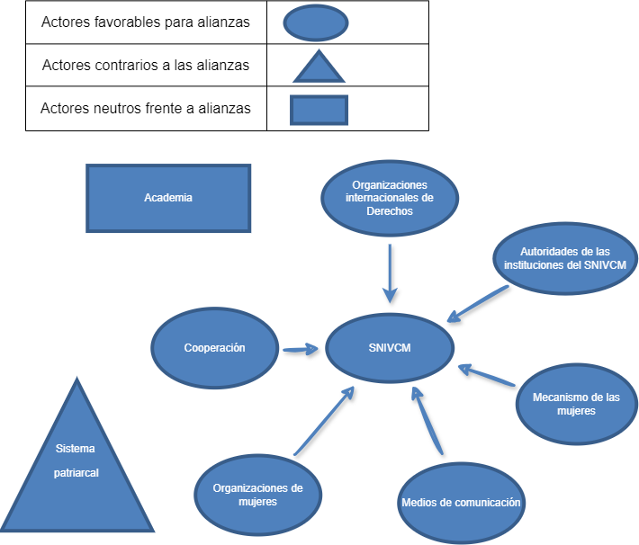

## 2.5 Poder-interes actores

Para el tratamiento y priorización de actores, su posición, fuerza e intensidad se sistematizó en una matriz de poder-interés que orienta mejor en la toma de decisiones para el Plan Interanual 2025-29, teniendo como resultado la Figura 6 donde se observa la tendencia de varios actores que ya se encuentran involucrados y que tienen interés e influencia para ser considerados en actividades que impulsen los derechos de las mujeres. A continuación se describe como se podría plantear el seguimiento a estos actores:

*Involucrar y atraer activamente:* es necesario gestionar estas relaciones cuidadosamente ya que su papel en los derechos de las mujeres es importante y aportan en gran manera al SNIVCM. Entre estos se encuentran las víctimas, agresores, SVET, SP, SEPREM, PNUD, PNC, PGN, PDH, ONU Mujeres, OJ, MSPAS, MP, MINGOB, Instituto de la Víctima, IJM, IDPP, CODISRA y los bufetes populares.

*Mantener informados:* para estos actores es necesario mantener y fortalecer los canales de comunicación, ya que, aunque no influyen directamente en el SNIVCM, sus aportes pueden resultar en valiosos apoyos y acompañamientos. Entre estos se puede mencionar Unidades de VCM de instituciones gubernamentales que dan acompañamiento o prestan algún servicio a las víctimas, sociedad civil y el INACIF.

*Monitorear:* es necesario dar seguimiento constante a estos actores, que, a pesar de que se encuentran en ruta de la VCM, su valoración puede cambiar ya sea a mayor fuerza e interés, o en el peor de los casos, disminuir estas valoraciones. Entre estos actores se encuentra el IGSS, INE, RENAP, SBN, CONADI, DEMI, CNA, MIDES, MINEX, Municipalidades, OSAR, ONG’s, Refugio de la niñez y las Universidades.

Figura 6: Gráfico de poder-interes actores

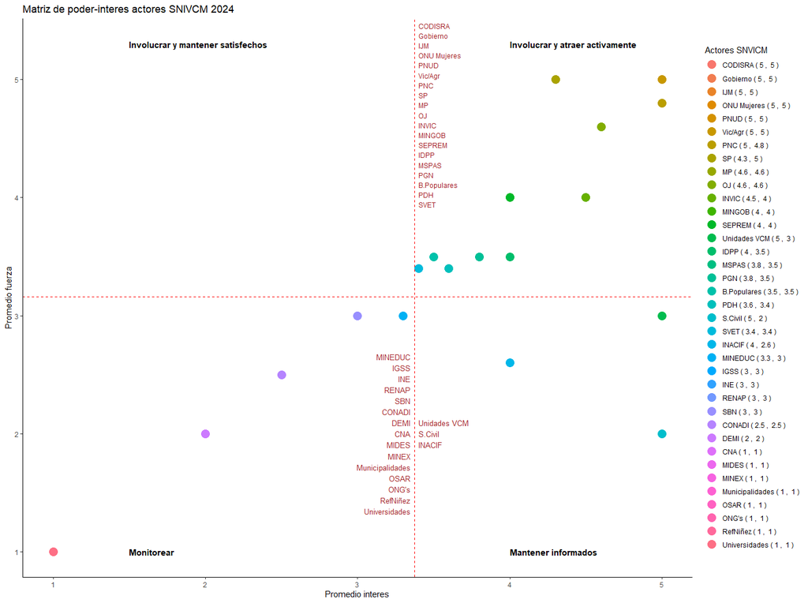

# 3 Análisis de resultados 2020-24

Para establecer las líneas estratégicas para los siguientes 4 años, un elemento de trascendencia es revisar los resultados que se han tenido según lo planificado para 2020-2024, lo cual se presenta en la Tabla 5, y a partir de ello construir la matriz multianual del nuevo plan 2025-29 (Tabla 6) teniendo en cuenta la retroalimentación de lecciones aprendidas con respecto a actividades que no se lograron realizar y los supuestos que influyeron para ello, así como la incorporación de nuevas actividades que contribuyen al fortalecimiento del SNIVCM.

Tabla 5: Resultados Plan Interanual 2020-2024

[output not shown]

# 4 Marco estratégico

## 4.1 Líneas estratégicas

Una vez establecido el problema central, causas, efectos, objetivos, fortalezas, debilidades, oportunidades, amenazas, actores y los resultados del último plan multianual, a continuación se define las líneas estratégicas del Plan Interanual 2025-29[^3]:

**Estrategia 1: Gestionar el fortalecimiento del SNIVCM:** Como se estableció en 2016-2019 y se continuó en 2020-24, la necesidad de tener un diálogo continuo con las y los tomadores de decisiones es fundamental para que el SNIVCM cumpla con sus objetivos.

La participación de las instituciones integrantes es estratégica para el apoyo de este proyecto, especialmente gestión y asignación de recursos y búsqueda de alianzas y para continuar con los procesos, especialmente cuando una de las debilidades recurrentes es la rotación de profesionales en las comisiones, debido al cambio en las designaciones. La continuidad de titulares y suplentes es necesaria para consolidar los procesos en el intercambio de información y cambios metodológicos que permitan mejorar la producción estadística.

Para el Plan 2025-29 se busca tener una gestión mediante una estrategia planificada cronológicamente con actividades y objetivos medibles y alcanzables para lograr el fortalecimiento de capacidades del SNIVCM con respecto a la gestión de información y producción continua de indicadores de VCM.

**Estrategia 2. Impulsar el diálogo con usuarias de información estadística:** Derivado del sondeo que se realizó en planes anteriores, se tuvieron apreciaciones por parte de usuarias y usuarios de información estadística de violencia contra la mujer donde había un reconocimiento de las personas consultadas sobre los esfuerzos para contar con el SNIVCM, pero también se identificó una solicitud en todos los usuarios para mejorar el ritmo en la producción de los datos, así como el acceso directo a la data de las fuentes primarias.

Esta situación mejoró de 2019 a 2024 con la publicación continua de indicadores, sin embargo dicha información es poco conocida por usuarias de información, por lo que para el plan 2025-29 se busca tener un diálogo más estrecho con estos usuarios para recibir sus aportes y cumplir con uno de los objetivos de la Declaración y Plataforma de Acción de Beijing, que indica que se debe “velar por que en cada país los productores y usuarios de las estadísticas revisen periódicamente la utilidad del sistema oficial de estadísticas y el grado en que mide las cuestiones de género, y elaborar un plan de las mejoras necesarias”.

**Estrategia 3. Fortalecimiento de los procesos de producción estadística:** Como parte del fortalecimiento de los procesos de producción estadística, es importante que el SNIVCM continúe con el intercambio de experiencias y con las capacitaciones con organismos, a estos retos pueden aportar los organismos internacionales especialistas en generación de estadísticas de violencia contra la mujer. Para el plan 2025-29 se tiene planificado establecer una ruta para la mejora en la calidad de los registros desde su captación, tendiendo en cuenta variables para el análisis interseccional que evidencie el impacto de la violencia contra la mujer mediante el monitoreo de indicadores.

Entre estas variables se busca priorizar el pueblo de pertenencia, sexo, edad, ocupación y discapacidad, tanto de la víctima como del agresor. En relación con el fortalecimiento de capacidades tecnológicas del SNIVCM, se llevarán a cabo actividades formativas de forma periódica con el uso de herramientas informáticas con las instituciones.

**Estrategia 4. Comunicación eficiente sobre el SNIVCM:** La forma en que la información se da a conocer a la población necesita de una estrategia adecuada, por ello mediante actividades de divulgación se espera crear contenido digital para dar a conocer la situación de la violencia contra las mujeres a nivel nacional, lo cual contribuye no solo a educar a la población sobre estereotipos, sesgos y enfoques inadecuados sobre las mujeres y las situaciones que les afectan, sino también a la generación de políticas públicas integrales con los datos que se generan en el SNIVCM.

Sin embargo, una de las situaciones que dificulta esta estrategia, es que el SNIVCM no cuente con recursos económicos propios, por lo que es necesario buscar financiamiento con cooperantes que contemplen en sus proyectos la prevención de la violencia contra la mujer para el desarrollo de campañas informativas.

## 4.2 Objetivos estratégicos

*Objetivo general:* Fortalecer la institucionalidad del SNIVCM para producir, analizar y difundir información confiable y oportuna que permita sustentar las acciones de decisiones sobre políticas públicas de prevención, atención, sanción y erradicación de la violencia contra las mujeres.

*Objetivos específicos:*

- Lograr un dialogo permanente con los diferentes actores del SNIVCM favorables en las alianzas estratégicas.
- Mejorar los procesos de producción estadística existentes para elevar la calidad de la información producida.
- Automatizar los procesos estadísticos del SNIVCM mediante herramientas informáticas eficientes.
- Potenciar los resultados del SNIVCM a través de la construcción de una estrategia de comunicación.

*Misión:* Somos el ente coordinador de las entidades relacionadas con la producción de estadísticas sobre violencia contra las mujeres para generar, recopilar, sistematizar y analizar la información que pueda orientar a los usuarios en la mejor comprensión y toma de decisiones para minimizar esta problemática.

*Visión:* Ser el organismo nacional reconocido como único ente rector a través del cual se recopile, integre, analice y difunda la información estadística sobre violencia contra las mujeres.

## 4.3 Actividades a realizar 2025-29

Tabla 6: Matriz multianual 2025-29

[output not shown]

# Conclusiones

- El SNIVCM es una de las experiencias más exitosas en materia de generación de información estadística procedente de un sin número de fuentes, logrando una coordinación sin precedentes en los registros administrativos.
- Aunque aún existen grandes retos por superar, la producción estadística del SNIVCM permite al Estado de Guatemala cumplir en gran parte en el cumplimiento de sus compromisos en materia de estadísticas sobre violencia contra la mujer.
- El plan multianual es una oportunidad para discutir lo que se ha considerado en este documento, como prioritario para los próximos 4 años, la problemática, estrategias y objetivos son el resultado de lo discutido a lo largo del año 2024 en los procesos de revisión de los instrumentos 2020-2024.
- La responsabilidad de coordinación del SNIVCM que tiene INE representa la necesidad de seguir reforzando a los equipos técnicos que generan la coordinación.

# Recomendaciones

- Es necesario reformar en los próximos 4 años el diálogo con las autoridades de las instituciones que conforman el SNIVCM para que las mismas sigan siendo referente del trabajo con los registros administrativos.
- Es importante que el plan estratégico sea conocido por las autoridades del INE y por las autoridades que conforman el SNIVCM, además debe socializarse con la cooperación internacional, en la búsqueda de recursos y alianzas.
- Fortalecer al SNIVCM creando la unidad de violencia contra la mujer con personal contratado de manera continua para responder a la demanda de coordinación del sistema, cumpliendo con los mandatos y recomendaciones al Estado de Guatemala en materia estadística de violencia contra la mujer.
- Dotar al SNIVCM con asignación presupuestaria para la ejecución de actividades

# Anexos

Tabla 7: Interrelación problemáticas matriz de Vester promediada

| No | Problema | P1 | P2 | P3 | P4 | P5 | P6 | P7 | P8 | P9 | P10 | P11 | Influencia |
| --- | --- | --- | --- | --- | --- | --- | --- | --- | --- | --- | --- | --- | --- |
| P1 | Métodos de análisis estadísticos deficientes | - | 1.3 | 1.7 | 1.1 | 1.5 | 1.9 | 1.9 | 1 | 1.2 | 1.1 | 1.3 | 14.0 |
| P2 | No se respeta el tiempo acordado para el envío de información por parte de las instituciones integrantes | 1.5 | - | 1.8 | 1.7 | 1.5 | 1.5 | 1.5 | 0.5 | 1.3 | 0.8 | 1.2 | 13.3 |
| P3 | Débil institucionalidad del SNIVCM | 1.8 | 1.9 | - | 1.5 | 1.9 | 1.8 | 1.8 | 1.4 | 1.8 | 1.7 | 1.7 | 17.3 |
| P4 | Alta rotación de personal en algunas comisiones | 1.2 | 1.8 | 1.8 | - | 1 | 1.5 | 1.4 | 1.2 | 1.8 | 0.8 | 0.9 | 13.4 |
| P5 | Desvinculación con mecanismos nacionales para el abordaje de la VCM | 1.4 | 1.2 | 1.8 | 0.7 | - | 1.5 | 1.3 | 1.4 | 1.6 | 0.7 | 1.4 | 13.0 |
| P6 | Falta de fortalecimiento para la calidad de los registros | 1.6 | 1.5 | 1.9 | 1.6 | 1.7 | - | 1.7 | 1.3 | 1.5 | 0.8 | 1.6 | 15.2 |
| P7 | Variables generales con información incompleta para el análisis de la problemática | 1.9 | 1.5 | 1.9 | 1.5 | 1.5 | 1.8 | - | 1.2 | 1.8 | 0.5 | 1.6 | 15.2 |
| P8 | Revíctimización de las víctimas por VCM debido a procedimiento deficientes para su abordaje | 1 | 0.5 | 1.6 | 1.2 | 1.4 | 1.2 | 1.3 | - | 1.8 | 1.1 | 1.5 | 12.6 |
| P9 | Voluntad política de autoridades | 1.2 | 1.5 | 1.8 | 1.6 | 1.6 | 1.5 | 1.9 | 1.9 | - | 1.8 | 1.7 | 16.5 |
| P10 | Falta de presupuesto para el SNIVCM | 1.2 | 0.9 | 1.6 | 0.8 | 1 | 1 | 0.6 | 1 | 1.8 | - | 1.7 | 11.6 |
| P11 | Falta de estrategia de comunicación | 1.3 | 1.1 | 1.8 | 1 | 1.4 | 1.7 | 1.5 | 1.1 | 1.7 | 1.7 | - | 14.3 |
|  | Dependencia | 14.1 | 13.2 | 17.7 | 12.7 | 14.5 | 15.4 | 14.9 | 12 | 16.3 | 11 | 14.6 | 156.4 |

Figura 7: Actividades 2025-29 SNIVCM

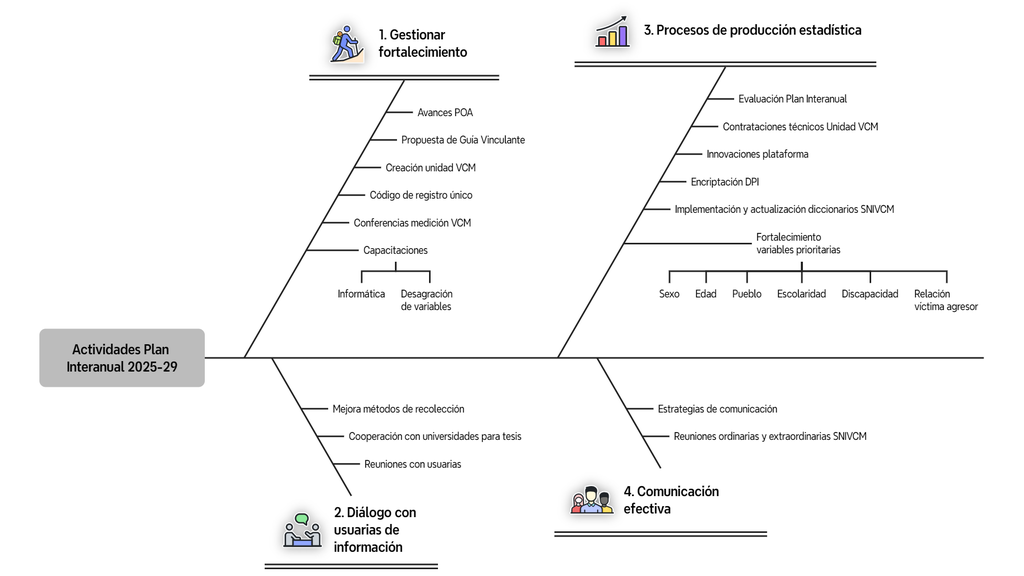

## Notas

[^1]: Según la “Convención De Belem Do Para”, “debe entenderse por violencia contra la mujer cualquier acción o conducta, basada en su género, que cause muerte, daño o sufrimiento físico, sexual o psicológico a la mujer, tanto en el ámbito público como en el privado”.
[^2]: Esta variable es requerida año con año, por la Comisión Económica para América Latina y el Caribe para el observatorio de Igualdad de Género, específicamente para el femicidio, sin embargo, Guatemala no ha cumplido con generarla.
[^3]: Consultar la Figura 7 en los anexos para orientar de manera sintética sobre las actividades a realizar para cada estrategia.